# MD exercises - Round 1

Sadip Giri

March 6, 2017

# Applying R basics

## Investigate the properties of a data frame

Read over the 2014 article from FiveThirtyEight.com entitled “Most Police Don’t Live In The Cities They Serve” (https://fivethirtyeight.com/datalab/most-police-dont-live-in-the-cities-they-serve/). Police and their relationships with citizens has been a controversial topic for many years and has come to the forefront of American culture since the events of Ferguson, Missouri mentioned in this article.

The dataset corresponding to this article from the fivethirtyeight package has been loaded as a data frame with name police_locals and is available in the workspace. You can view the police_locals data frame as an interactive table here.

To work with functions and/or data stored in an R package, we need to first load the package using the library function. This is done for you with both the tibble package and the fivethirtyeight package. The data function loads the specified data set (passed as an argument to data) into the environment.

```r
library(tibble)
library(fivethirtyeight)
```

```r
data(police_locals)
```

Get the names of the columns/variables in `police_locals` using the `names` function.

```r
# police_locals is available in your workspace
# Identify the names of the columns in police_locals
names(police_locals)
```

```
## [1] "city"       "force_size" "all"        "white"      "non_white"
## [6] "black"      "hispanic"   "asian"
```

Check out the properties of `police_locals` using the `glimpse` function in the `tibble package`. (This function acts much like the `str` function, but has some nicer features.)

```r
# Check out the properties of police_locals
glimpse(police_locals)
```

```
## Observations: 75
## Variables: 8
## $ city       <chr> "New York", "Chicago", "Los Angeles", "Washington",...
## $ force_size <int> 32300, 12120, 10100, 9340, 7700, 6045, 4475, 4460, ...
## $ all        <dbl> 0.6179567, 0.8750000, 0.2282178, 0.1156317, 0.29220...
## $ white      <dbl> 0.44638656, 0.87196262, 0.15277778, 0.05677419, 0.1...
## $ non_white  <dbl> 0.7644189, 0.8774003, 0.2638484, 0.1573651, 0.39925...
## $ black      <dbl> 0.7708914, 0.8974057, 0.3873874, 0.1701891, 0.36637...
## $ hispanic   <dbl> 0.76286073, 0.83982684, 0.21767956, 0.08988764, 0.4...
## $ asian      <dbl> 0.7492355, 0.9666667, 0.3052632, 0.2307692, 0.40816...
```

## Identify observational unit

What is the observational unit in this `police_locals` data frame? You can view the `police_locals` data frame as an interactive table here: https://ismayc.github.io/Effective-Data-Storytelling-using-the-tidyverse/police_locals.html.

Possible Answers: A) Percentage of officers B) City C) Police force D) Race

ANSWER: B

## Create a vector

One of the cool features of R is that works quickly and easily with vectors. Test your knowledge from the Introduction to R DataCamp course by determining the vector specified below.

- Create a new vector called `all_not` that calculates the percentage of the total police force that DO NOT live in the city. Note that `all_not` should not be included in the `police_locals` data frame but instead live as a vector by itself.
- You can get information on what each of the different variables in `police_locals` represents by entering `?police_locals` in the R Console or by going here.
- NOTE: The best way to extract a vector from a data frame is to use $.

```r
all_not<-1-(police_locals$all)
all_not # printing to see what's happening
```

```
##  [1] 0.38204334 0.12500000 0.77178218 0.88436831 0.70779221 0.16459884
##  [7] 0.68826816 0.63789238 0.80859917 0.62940276 0.68377483 0.37563452
## [13] 0.86271186 0.62544170 0.74285714 0.52343750 0.19057816 0.14823009
## [19] 0.59465479 0.44254279 0.60148515 0.72069825 0.70528967 0.53553300
## [25] 0.27806122 0.53333333 0.92741936 0.71703297 0.92032967 0.63764045
## [31] 0.82215743 0.35185185 0.90566038 0.50000000 0.90522876 0.88235294
## [37] 0.40333333 0.88235294 0.22222222 0.38194444 0.06271777 0.57342657
## [43] 0.35314685 0.78245614 0.79779412 0.34074074 0.38432836 0.74786325
## [49] 0.73043478 0.90000000 0.77292576 0.70852018 0.77477478 0.40000000
## [55] 0.21028037 0.48557692 0.66336634 0.90000000 0.79000000 0.66000000
## [61] 0.89000000 0.78571429 0.60937500 0.78010471 0.83157895 0.41052632
## [67] 0.48648649 0.81460674 0.39534884 0.78488372 0.42441860 0.43478261
## [73] 0.72151899 0.14285714 0.72847682
```

## Subset and index a vector

Use `[ ]` to extract specific information about a variable in the `police_locals` data frame.

Extract the first, seventh, sixty-sixth, and seventy-third city names from the data set in one R command.

```r
police_locals[c(1, 7, 66, 73), 1]
```

```
## # A tibble: 4 × 1
##            city
##           <chr>
## 1      New York
## 2       Phoenix
## 3     St. Louis
## 4 Madison, Wis.
```

Assign `sub_cities` as the name to this object

```r
sub_cities <- police_locals[c(1,7,66,73), 1]
#another way of doing it
#sub_cities <- police_locals$city[c(1,7,66,73)]
```

## Subset and index a vector again.

In R, an index refers to the specific entry in an object. As an example, in a vector called my_vec defined as `my_vec <- c(200, 243, 78)`, index 1 corresponds to 200, index 2 corresponds to 243, and index 3 corresponds to 78.

Extract the police size forces corresponding to indices 14 to 39 in `police_locals` and assign the `pol_force` name to this subset.

```r
#pol_force <- police_locals[14:39, 2]
#another way of doing it
pol_force <- police_locals$force_size[c(14:39)]
pol_force # returning it so that I can confirm the results of that pol_force variable
```

```
##  [1] 2830 2800 2560 2335 2260 2245 2045 2020 2005 1985 1970 1960 1875 1860
## [15] 1820 1820 1780 1715 1620 1590 1560 1530 1530 1500 1445 1440
```

# Tidy Data

## Joining data frames

Recall the`police_locals` data frame you worked with in Applying R Basics as an interactive table here: https://ismayc.github.io/Effective-Data-Storytelling-using-the-tidyverse/police_locals.html.

There has been much discussion about the political divide that exists in the US. A separate data frame has been loaded with the name `ideology` that lists cities, their state, and the political ideology of the state. Created somewhat naively, a description of this `state_ideology` variable follows.

`state_ideology`: For each city in the dataset, a look-up of the state the city resides in and the results of the 2016 Presidential election were given. If Clinton won the state in 2016, “`Liberal`” is the value for `state_ideology`. If Trump won the state in 2016, “`Conservative`” is the value for `state_ideology`.

An interactive table of the `ideology` data frame is here: https://ismayc.github.io/Effective-Data-Storytelling-using-the-tidyverse/ideology.html.

Instructions:

- Use the `inner_join` function in the dplyr package to add the state and `state_ideology` columns to the `police_locals` data frame where the key variable is city in both data frames. (Note the use of `library(dplyr)` here. You will always need to load the package first if you would like to use the functions inside it.)
- `inner_join(x = , y = , by = " ")`
- Recall that the main arguments to `inner_join` are `x`, `y`, and `by`. `x` corresponds to the data frame you would like to add columns to. `y` corresponds to the data frame you’d like to add columns from. by corresponds to the name (or names) of the key vectors that you’d like to join the two data frames together by. Note that the names of the variables for by must be inside quotation marks.
- Assign the name `police_join` to this expanded data frame.

```r
library(dplyr)
library(readr)
ideology <- read_csv("http://s3.amazonaws.com/assets.datacamp.com/production/course_3085/datasets/ideology.csv")
```

```r
#ideology <- readLines("http://s3.amazonaws.com/assets.datacamp.com/production/course_3085/datasets/ideology.csv")

# Join police_locals with ideology by city
# Provide police_join as the name
police_join <- inner_join(x = police_locals, y = ideology, by = "city")

#observe some of the changes using glimpse function
glimpse(police_join)    # Great, it worked
```

```
## Observations: 75
## Variables: 10
## $ city           <chr> "New York", "Chicago", "Los Angeles", "Washingt...
## $ force_size     <int> 32300, 12120, 10100, 9340, 7700, 6045, 4475, 44...
## $ all            <dbl> 0.6179567, 0.8750000, 0.2282178, 0.1156317, 0.2...
## $ white          <dbl> 0.44638656, 0.87196262, 0.15277778, 0.05677419,...
## $ non_white      <dbl> 0.7644189, 0.8774003, 0.2638484, 0.1573651, 0.3...
## $ black          <dbl> 0.7708914, 0.8974057, 0.3873874, 0.1701891, 0.3...
## $ hispanic       <dbl> 0.76286073, 0.83982684, 0.21767956, 0.08988764,...
## $ asian          <dbl> 0.7492355, 0.9666667, 0.3052632, 0.2307692, 0.4...
## $ state          <chr> "New York", "Illinois", "California", "DC", "Te...
## $ state_ideology <chr> "Liberal", "Liberal", "Liberal", "Liberal", "Co...
```

## Change in observational unit?

Does the `police_join` data frame have a different observational unit than the `police_locals` data frame?

Possible Answers: A) Yes, the observational unit is now state. B) Yes, we have added rows to police_join so the observational unit must have changed. C) No, the observational unit is still the same as it was for police_locals. D) None of the above.

ANSWER: C

## Is it tidy?

Recall that a tidy data frame must have three properties:

- Each variable forms a column.
- Each observation forms a row.
- Each type of observational unit forms a table.

Is the police_join data frame tidy?

Possible Answers: A) Yes, it is neat and easy-to-read. B) Yes, it follows all of the requirements of a tidy data set as given above. C) No, it does not meet all of the requirements of a tidy data set. D) None of the above are correct.}

ANSWER: C (Because same column is being used several times like asian, white.. which I think belong to same type of race)

## Another join

There may be many reasons for police officers to not live in the same cities as they serve. One potential reason that has been suggested is that the cost of living in some areas is much higher than in other nearby areas. The Missouri Economic Research and Information Center created a table of the Composite Cost of Living (Scaled) by US state for the third quarter of 2016 here. This data has been loaded as a data frame with the name `cost_of_living` available to view here . As shown on the map at the link, the overall index is given in `cost_of_living` for each state and categories of “high”, “mid”, and “low” are created in the `col_group` variable following the ranges on the map.

Instructions:

- Use the inner_join function in the dplyr package to look-up and add the index and col_group variables to the police_join data frame. (Note that you’ll need to think about what the key variable is here.)
- Assign a name of your choosing to this expanded data frame.

```r
cost_of_living <- read_csv("http://s3.amazonaws.com/assets.datacamp.com/production/course_3085/datasets/cost_of_living.csv")
```

```r
#cost_of_living <- readLines("http://s3.amazonaws.com/assets.datacamp.com/production/course_3085/datasets/cost_of_living.csv")

newDataFrame <- inner_join(x = police_join, y = cost_of_living, by = "state")

glimpse(newDataFrame)
```

```
## Observations: 73
## Variables: 12
## $ city           <chr> "New York", "Chicago", "Los Angeles", "Houston"...
## $ force_size     <int> 32300, 12120, 10100, 7700, 6045, 4475, 4460, 36...
## $ all            <dbl> 0.6179567, 0.8750000, 0.2282178, 0.2922078, 0.8...
## $ white          <dbl> 0.44638656, 0.87196262, 0.15277778, 0.17373461,...
## $ non_white      <dbl> 0.7644189, 0.8774003, 0.2638484, 0.3992583, 0.8...
## $ black          <dbl> 0.7708914, 0.8974057, 0.3873874, 0.3663793, 0.9...
## $ hispanic       <dbl> 0.7628607, 0.8398268, 0.2176796, 0.4571429, 0.8...
## $ asian          <dbl> 0.7492355, 0.9666667, 0.3052632, 0.4081633, NA,...
## $ state          <chr> "New York", "Illinois", "California", "Texas", ...
## $ state_ideology <chr> "Liberal", "Liberal", "Liberal", "Conservative"...
## $ index          <dbl> 131.0, 94.6, 135.9, 90.7, 101.4, 98.0, 135.9, 9...
## $ col_group      <chr> "high", "low", "high", "low", "mid", "mid", "hi...
```

## Is this tidy?

Read over another 2014 article from FiveThirtyEight.com entitled “The Dollar-And-Cents Case Against Hollywood’s Exclusion of Women” here: https://fivethirtyeight.com/features/the-dollar-and-cents-case-against-hollywoods-exclusion-of-women/. We’ll be working with a data used in this story stored as a data frame with name bechdel in the fivethirtyeight package.

Is the bechdel data frame tidy? You can view an interactive table of it here: https://ismayc.github.io/Effective-Data-Storytelling-using-the-tidyverse/bechdel.html.

Possible Answers: A) Yes, it is neat and easy-to-read. B) Yes, it follows all of the requirements of a tidy data set as given above. C) No, it does not meet all of the requirements of a tidy data set. D) None of the above are correct.

ANSWER: B

## What’s the observational unit?

What is the observational unit in the bechdel data frame?

Possible Answers: A) Budget of the movie B) Movie C) Whether or not a movie passes the Bechdel Test D) None of the above

ANSWER: B

# Histograms and Boxplots

## Histograms

Recall the `police_join_cost` data frame that was created earlier.

Instructions:

- Create a histogram for viewing the distribution of residency of white police officers.
- The histogram should have five bins, fill color of “navyblue”, and border color of “white”.

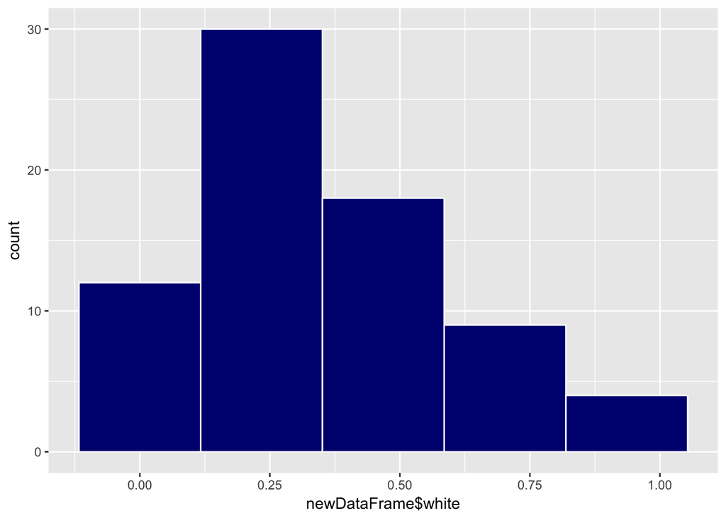

````r
# what is this?
# Recall the ```police_join_cost``` data frame that was created earlier.
# Does that mean - data frame created just before?
library(ggplot2)
ggplot(data = newDataFrame, mapping = aes(x = newDataFrame$white)) +
        geom_histogram(bins = 5, color = "white", fill = "navyblue")
````

## Making an appropriate plot

We will again look at `police_join_cost` which was created earlier.

Instructions

- Create an appropriate plot for viewing the distribution of residency of non-white police officers.
- The plot should group the data into 5 groups with the bins having yellow color and a black border.

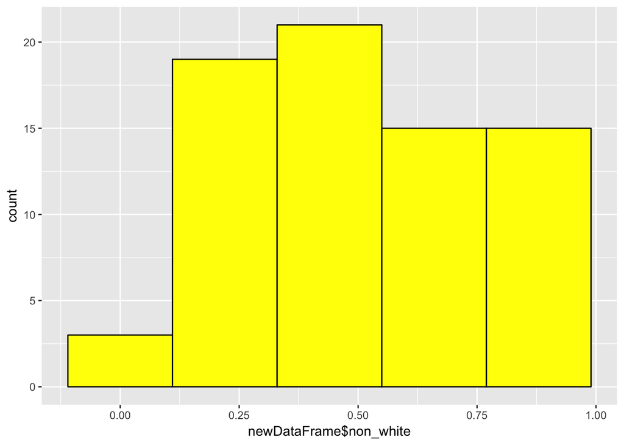

```r
ggplot(data = newDataFrame, mapping = aes(x = newDataFrame$non_white)) +
        geom_histogram(color = "black", bins = 5, fill = "yellow")
```

```r
#
# color in geom_histogram() changes Border colour where as fill will change the colour of the bins
```

## Problems with non-tidy data

Recall that `police_join_cost` is not a tidy data set. In fact, white and non_white being the names of variables that contain percentage values doesn’t really make sense either and the Grammar of Graphics framework makes plotting this non-tidy data set challenging.

Instructions

- Produce a boxplot looking at the relationship between `race` and `reside_perc`.

```r
# where is reside_perc???
#ggplot(data = newDataFrame, mapping = aes(x = white, y = reside_perc)) +
#  geom_boxplot()
# ?? Confused
```

## Explanatory and Response Variables

True or False: In the previous exercise, `race` is the response variable and `reside_perc` is the explanatory variable.

Is this statement true or false? Please explain. False (I think, race explains (affects) reside_perc which is being responded)

## Faceting

Another way to view the distribution of a response variable across the levels of an explanatory variable is by using a faceted histogram.

Instructions:

- Produce a histogram with binwidth of 0.2 and white border color of `reside_perc` faceted by the levels of `state_ideology`.

```r
# where is that reside_perc?

#ggplot(data = newDataFrame, mapping = aes(x = newDataFrame$reside_perc)) +
#        geom_histogram(binwidth = 0.2, color = "white") +
#        facet_wrap(~ state_ideology)
```

## Faceting again

Recall from the Scatter-plots & Line-graphs chapter that cities in liberal states tend to have cost of living index values that are higher than cities in conservative states.

Instructions:

- Produce a histogram with binwidth of 0.2 and white border color of `reside_perc` faceted by the levels of `col_group` for the `police_tidy` data.
- This time use the `facet_grid` function to display the histograms on top of each other instead of side-by-side.

```r
# same problem where is reside_perc?
#ggplot(data = newDataFrame, mapping = aes(x = reside_perc)) +
#        geom_histogram(color = "white", binwidth = 0.2) +
#        facet_grid(~col_group)
```